# Building and Using Ensembl-based Annotation Packages with ensembldb

June 26, 2016

## Building and Using Ensembl-based Annotation Packages with `ensembldb`

**Johannes Rainer** (EURAC), BioC 2016 Stanford

Clone me @GitHub: http://github.com/jotsetung/Bioc2016-ensembldb.

## Introduction

- `TxDb` objects from `GenomicFeatures` provide gene model annotations:
  - Used for RNA-seq, CHiP-seq, etc.
  - Providing mostly UCSC annotations.
- `ensembldb` package defines the `EnsDb` class:
  - Same functionality as `TxDb` objects, **plus**:
  - Designed for Ensembl: **all** genes, attributes *gene biotype* and *tx biotype*.
  - Allows to query specific annotations using a simple **filter framework**.

## Usage: Query gene, transcript, exon information

- Available methods to extract data:
  - `genes`
  - `transcripts`
  - `transcriptsBy`
  - `exons`
  - `exonsBy`
  - `cdsBy`
  - `fiveUTRsByTranscripts`
  - `threeUTRsByTranscripts`

**Example**: get all genes' annotations.

```r
## Load an EnsDb package matching Ensembl version 81
library(EnsDb.Hsapiens.v81)
edb <- EnsDb.Hsapiens.v81

## Now just get all genes
genes(edb)
```

```
## GRanges object with 66563 ranges and 5 metadata columns:
##                     seqnames                 ranges strand |
##                        <Rle>              <IRanges>  <Rle> |
##   ENSG00000278806 KI270752.1            [144,  268]      + |
##   ENSG00000210049         MT            [577,  647]      + |
##   ENSG00000211459         MT            [648, 1601]      + |
##               ...        ...                    ...    ... .
##   ENSG00000185220          1 [248906196, 248919946]      + |
##   ENSG00000200495          1 [248912690, 248912795]      - |
##   ENSG00000233084          1 [248936581, 248937043]      + |
##                           gene_id   gene_name    entrezid
##                       <character> <character> <character>
##   ENSG00000278806 ENSG00000278806  AF065393.4
##   ENSG00000210049 ENSG00000210049       MT-TF
##   ENSG00000211459 ENSG00000211459     MT-RNR1
##               ...             ...         ...         ...
##   ENSG00000185220 ENSG00000185220       PGBD2      267002
##   ENSG00000200495 ENSG00000200495  RNU6-1205P
##   ENSG00000233084 ENSG00000233084   RPL23AP25
##                           gene_biotype seq_coord_system
##                            <character>      <character>
##   ENSG00000278806                miRNA         scaffold
##   ENSG00000210049              Mt_tRNA       chromosome
##   ENSG00000211459              Mt_rRNA       chromosome
##               ...                  ...              ...
##   ENSG00000185220       protein_coding       chromosome
##   ENSG00000200495                snRNA       chromosome
##   ENSG00000233084 processed_pseudogene       chromosome
##   -------
##   seqinfo: 338 sequences from GRCh38 genome
```

**Example**: get all genes encoded on chromosome Y.

```r
## Define a chromsome filter for Y.
sf <- SeqnameFilter("Y")

## Retrieve the data
genes(edb, filter=sf)
```

```
## GRanges object with 545 ranges and 5 metadata columns:
##                   seqnames               ranges strand |         gene_id
##                      <Rle>            <IRanges>  <Rle> |     <character>
##           LRG_186        Y   [1268800, 1309935]      + |         LRG_186
##   ENSG00000251841        Y   [2784749, 2784853]      + | ENSG00000251841
##   ENSG00000184895        Y   [2786855, 2787699]      - | ENSG00000184895
##               ...      ...                  ...    ... .             ...
##   ENSG00000237917        Y [26594851, 26634652]      - | ENSG00000237917
##   ENSG00000231514        Y [26626520, 26627159]      - | ENSG00000231514
##   ENSG00000235857        Y [56855244, 56855488]      + | ENSG00000235857
##                     gene_name    entrezid           gene_biotype
##                   <character> <character>            <character>
##           LRG_186     LRG_186        1438               LRG_gene
##   ENSG00000251841  RNU6-1334P                              snRNA
##   ENSG00000184895         SRY        6736         protein_coding
##               ...         ...         ...                    ...
##   ENSG00000237917     PARP4P1             unprocessed_pseudogene
##   ENSG00000231514     FAM58CP               processed_pseudogene
##   ENSG00000235857     CTBP2P1               processed_pseudogene
##                   seq_coord_system
##                        <character>
##           LRG_186       chromosome
##   ENSG00000251841       chromosome
##   ENSG00000184895       chromosome
##               ...              ...
##   ENSG00000237917       chromosome
##   ENSG00000231514       chromosome
##   ENSG00000235857       chromosome
##   -------
##   seqinfo: 1 sequence from GRCh38 genome
```

## Available filters

- For genes:
  - `GeneidFilter`
  - `GenenameFilter`
  - `EntrezidFilter`
  - `GenebiotypeFilter`
- For transcripts:
  - `TxidFilter`
  - `TxbiotypeFilter`
- For exons:
  - `ExonidFilter`
  - `ExonrankFilter`

## Available filters

- *Generic* filters:
  - `SeqnameFilter`
  - `SeqstrandFilter`
  - `SeqstartFilter`
  - `SeqendFilter`
  - `GRangesFilter`: condition can be *within* or *overlapping*.
- Multiple filters are combined with a logical *AND*.
- Each filter supports 1:n values and also a *like* condition.

**Example**: combine filters.

```r
## Example for a GRangesFilter; condition could be "within" or "overlapping"
grf <- GRangesFilter(GRanges(17, IRanges(59000000, 59200000)), condition="within")

## Combine with a GenebiotypeFilter to get all genes except pre-miRNAs and snRNAs.
genes(edb, filter=list(grf, GenebiotypeFilter(c("miRNA", "snRNA"), condition="!=")))
```

```
## GRanges object with 4 ranges and 5 metadata columns:
##                   seqnames               ranges strand |         gene_id
##                      <Rle>            <IRanges>  <Rle> |     <character>
##   ENSG00000263558       17 [59059226, 59059493]      + | ENSG00000263558
##   ENSG00000224738       17 [59106598, 59118267]      + | ENSG00000224738
##   ENSG00000182628       17 [59109951, 59155269]      - | ENSG00000182628
##   ENSG00000266537       17 [59174983, 59181787]      - | ENSG00000266537
##                     gene_name    entrezid           gene_biotype
##                   <character> <character>            <character>
##   ENSG00000263558   RN7SL716P                           misc_RNA
##   ENSG00000224738  AC099850.1                          antisense
##   ENSG00000182628        SKA2      348235         protein_coding
##   ENSG00000266537    SPDYE22P             unprocessed_pseudogene
##                   seq_coord_system
##                        <character>
##   ENSG00000263558       chromosome
##   ENSG00000224738       chromosome
##   ENSG00000182628       chromosome
##   ENSG00000266537       chromosome
##   -------
##   seqinfo: 1 sequence from GRCh38 genome
```

## `ensembldb` and the `AnnotationDbi` API

- `EnsDb` support all `AnnotationDbi` methods **with filters**.
- **Example**: use `AnnotationDbi`'s `select` method to fetch annotation.

```r
## Get all data for the gene SKA2
Res <- select(edb, keys="SKA2", keytype="GENENAME")
head(Res, n=3)
```

```
##   ENTREZID          EXONID EXONIDX EXONSEQEND EXONSEQSTART    GENEBIOTYPE
## 1   348235 ENSE00001324111       1   59155269     59155131 protein_coding
## 2   348235 ENSE00003636954       2   59131367     59131281 protein_coding
## 3   348235 ENSE00003478713       3   59119495     59119319 protein_coding
##            GENEID GENENAME GENESEQEND GENESEQSTART ISCIRCULAR
## 1 ENSG00000182628     SKA2   59155269     59109951          0
## 2 ENSG00000182628     SKA2   59155269     59109951          0
## 3 ENSG00000182628     SKA2   59155269     59109951          0
##   SEQCOORDSYSTEM SEQLENGTH SEQNAME SEQSTRAND      TXBIOTYPE TXCDSSEQEND
## 1     chromosome  83257441      17        -1 protein_coding    59155163
## 2     chromosome  83257441      17        -1 protein_coding    59155163
## 3     chromosome  83257441      17        -1 protein_coding    59155163
##   TXCDSSEQSTART            TXID          TXNAME TXSEQEND TXSEQSTART
## 1      59112277 ENST00000330137 ENST00000330137 59155269   59109951
## 2      59112277 ENST00000330137 ENST00000330137 59155269   59109951
## 3      59112277 ENST00000330137 ENST00000330137 59155269   59109951
```

… continued.

```r
## What keytypes can be used?
keytypes(edb)
```

```
##  [1] "ENTREZID"    "EXONID"      "GENEBIOTYPE" "GENEID"      "GENENAME"
##  [6] "SEQNAME"     "SEQSTRAND"   "TXBIOTYPE"   "TXID"        "TXNAME"
```

- Use filters to have more control on the query.

```r
## For the gene SKA2, get all exons except exon 1 and 2 for all tx targeted
## for nonsense mediated decay.
select(edb, keys=list(GenenameFilter("SKA2"),
                      ExonrankFilter(1:2, condition="!="),
                      TxbiotypeFilter("nonsense_mediated_decay")))
```

```
##   ENTREZID          EXONID EXONIDX EXONSEQEND EXONSEQSTART    GENEBIOTYPE
## 1   348235 ENSE00002710994       3   59124428     59124307 protein_coding
## 2   348235 ENSE00003552567       4   59119495     59119319 protein_coding
## 3   348235 ENSE00002729093       5   59112345     59111890 protein_coding
## 4   348235 ENSE00003594135       3   59119495     59119319 protein_coding
## 5   348235 ENSE00002695019       4   59112345     59112262 protein_coding
##            GENEID GENENAME GENESEQEND GENESEQSTART ISCIRCULAR
## 1 ENSG00000182628     SKA2   59155269     59109951          0
## 2 ENSG00000182628     SKA2   59155269     59109951          0
## 3 ENSG00000182628     SKA2   59155269     59109951          0
## 4 ENSG00000182628     SKA2   59155269     59109951          0
## 5 ENSG00000182628     SKA2   59155269     59109951          0
##   SEQCOORDSYSTEM SEQLENGTH SEQNAME SEQSTRAND               TXBIOTYPE
## 1     chromosome  83257441      17        -1 nonsense_mediated_decay
## 2     chromosome  83257441      17        -1 nonsense_mediated_decay
## 3     chromosome  83257441      17        -1 nonsense_mediated_decay
## 4     chromosome  83257441      17        -1 nonsense_mediated_decay
## 5     chromosome  83257441      17        -1 nonsense_mediated_decay
##   TXCDSSEQEND TXCDSSEQSTART            TXID          TXNAME TXSEQEND
## 1    59155163      59124363 ENST00000578519 ENST00000578519 59155182
## 2    59155163      59124363 ENST00000578519 ENST00000578519 59155182
## 3    59155163      59124363 ENST00000578519 ENST00000578519 59155182
## 4    59155083      59119474 ENST00000583976 ENST00000583976 59155177
## 5    59155083      59119474 ENST00000583976 ENST00000583976 59155177
##   TXSEQSTART
## 1   59111890
## 2   59111890
## 3   59111890
## 4   59112262
## 5   59112262
```

## Annotation for feature counting

- `exonsBy`: provide gene model information for feature counting.
- **Example**: get gene models for `GenomicAlignments`' `summarizeOverlaps` method.

```r
library(GenomicAlignments)
library(BiocParallel)
## Get exons by gene, for chromosomes 1:22, X, Y, excluding locus reference
## genomic genes (LRG)
exns <- exonsBy(edb, by="gene", filter=list(SeqnameFilter(c(1:22, "X", "Y")),
                                            GeneidFilter("ENSG%", "like")))

bfl <- BamFileList(dir("data/bam", pattern=".bam$", full.names=TRUE), asMates=TRUE,
                   yieldSize=1e+6, obeyQname=TRUE)
## Define a ScanBamParam with a mapping quality filter.
sbp <- ScanBamParam(mapqFilter=30)

## Do the gene counting
geneCounts <- bplapply(bfl, FUN=summarizeOverlaps, features=exns, mode="IntersectionStrict",
                       ignore.strand=TRUE, singleEnd=FALSE, fragments=TRUE, param=sbp)
geneCounts <- do.call(cbind, geneCounts)
```

- **Example**: gene models for `Rsubread`'s `featureCount`.

```r
## Convert the exon list to SAF format
saf <- toSAF(exns)

####
##  Do the feature counting using the Rsubread package
library(Rsubread)
bamf <- dir("data/bam", pattern=".bam$", full.names=TRUE)
cnts <- featureCounts(files=bamf, annot.ext=saf, isPairedEnd=TRUE, nthreads=1)
```

## Integrating UCSC and Ensembl annotations

- UCSC and Ensembl use different chromosome naming styles.
- **Example**: How to integrate Ensembl based annotations with UCSC data?

```r
## Get chromosome names; they are different from UCSC style (chr1, ...)
head(seqlevels(edb))
```

```
## [1] "1"  "10" "11" "12" "13" "14"
```

```r
## Get genes on chromsome Y, UCSC style:
genes(edb, filter=SeqnameFilter("chrY"))
```

```
## GRanges object with 0 ranges and 5 metadata columns:
##    seqnames    ranges strand |     gene_id   gene_name    entrezid
##       <Rle> <IRanges>  <Rle> | <character> <character> <character>
##    gene_biotype seq_coord_system
##     <character>      <character>
##   -------
##   seqinfo: no sequences
```

… continued.

```r
## Solution: change the chromosome naming style of the EnsDb:
seqlevelsStyle(edb) <- "UCSC"

genes(edb, filter=SeqnameFilter("chrY"))
```

```
## GRanges object with 545 ranges and 5 metadata columns:
##                   seqnames               ranges strand |         gene_id
##                      <Rle>            <IRanges>  <Rle> |     <character>
##           LRG_186     chrY   [1268800, 1309935]      + |         LRG_186
##   ENSG00000251841     chrY   [2784749, 2784853]      + | ENSG00000251841
##   ENSG00000184895     chrY   [2786855, 2787699]      - | ENSG00000184895
##               ...      ...                  ...    ... .             ...
##   ENSG00000237917     chrY [26594851, 26634652]      - | ENSG00000237917
##   ENSG00000231514     chrY [26626520, 26627159]      - | ENSG00000231514
##   ENSG00000235857     chrY [56855244, 56855488]      + | ENSG00000235857
##                     gene_name    entrezid           gene_biotype
##                   <character> <character>            <character>
##           LRG_186     LRG_186        1438               LRG_gene
##   ENSG00000251841  RNU6-1334P                              snRNA
##   ENSG00000184895         SRY        6736         protein_coding
##               ...         ...         ...                    ...
##   ENSG00000237917     PARP4P1             unprocessed_pseudogene
##   ENSG00000231514     FAM58CP               processed_pseudogene
##   ENSG00000235857     CTBP2P1               processed_pseudogene
##                   seq_coord_system
##                        <character>
##           LRG_186       chromosome
##   ENSG00000251841       chromosome
##   ENSG00000184895       chromosome
##               ...              ...
##   ENSG00000237917       chromosome
##   ENSG00000231514       chromosome
##   ENSG00000235857       chromosome
##   -------
##   seqinfo: 1 sequence from GRCh38 genome
```

- **Use case**: get SKA2 tx sequences using BSgenome.

```r
library(BSgenome.Hsapiens.UCSC.hg38)

ska2tx <- exonsBy(edb, by="tx", filter=GenenameFilter("SKA2"))
extractTranscriptSeqs(BSgenome.Hsapiens.UCSC.hg38, ska2tx)
```

```
##   A DNAStringSet instance of length 10
##      width seq                                         names
##  [1]  2798 AATGAGTGCGAGATGTTGAG...CTACAATCCTCTTTCTAAAA ENST00000330137
##  [2]   625 GCCGCGGTCTGCGGAATGTC...GAGAATAAAACGATTTAAAT ENST00000437036
##  [3]   689 GCGGAATGTCAACTATTCAA...ACATTTCAGTCATTCGGTAT ENST00000578105
##  [4]   894 GGAATGTCAACTATTCAACA...GTACATTTCAGTCATTCGGT ENST00000578519
##  [5]   689 GCGGAATGTCAACTATTCAA...ATTTCAGTCATTCGGTATGT ENST00000580541
##  [6]   595 GACAGCTGTCCAATGGAGGC...CATCTGTTTTCTTTTTCTAA ENST00000581068
##  [7]   583 AACTATTCAACATGGAGGCG...AGGGCAGATAATATATGAAT ENST00000583380
##  [8]   533 GAGATGTTGAGTGACAGCTG...TTTCTAAGTCATGATAATAT ENST00000583927
##  [9]   570 GTCAACTATTCAACATGGAG...TATGAAGAAATGGACTTGGA ENST00000583976
## [10]   229 CTTAGTAAACTCAAGATAAA...GCAGAAAGAGAGTAAGAGCC ENST00000584089
```

- **Preferred way**: get the `FaFile` corresponding to the correct genome build using the dedicated `getGenomeFaFile` method.

```r
faf <- getGenomeFaFile(edb)
seqlevelsStyle(edb) <- "Ensembl"
extractTranscriptSeqs(faf, exonsBy(edb, by="tx", filter=GenenameFilter("SKA2")))
```

```
##   A DNAStringSet instance of length 10
##      width seq                                         names
##  [1]  2798 AATGAGTGCGAGATGTTGAG...CTACAATCCTCTTTCTAAAA ENST00000330137
##  [2]   625 GCCGCGGTCTGCGGAATGTC...GAGAATAAAACGATTTAAAT ENST00000437036
##  [3]   689 GCGGAATGTCAACTATTCAA...ACATTTCAGTCATTCGGTAT ENST00000578105
##  [4]   894 GGAATGTCAACTATTCAACA...GTACATTTCAGTCATTCGGT ENST00000578519
##  [5]   689 GCGGAATGTCAACTATTCAA...ATTTCAGTCATTCGGTATGT ENST00000580541
##  [6]   595 GACAGCTGTCCAATGGAGGC...CATCTGTTTTCTTTTTCTAA ENST00000581068
##  [7]   583 AACTATTCAACATGGAGGCG...AGGGCAGATAATATATGAAT ENST00000583380
##  [8]   533 GAGATGTTGAGTGACAGCTG...TTTCTAAGTCATGATAATAT ENST00000583927
##  [9]   570 GTCAACTATTCAACATGGAG...TATGAAGAAATGGACTTGGA ENST00000583976
## [10]   229 CTTAGTAAACTCAAGATAAA...GCAGAAAGAGAGTAAGAGCC ENST00000584089
```

## Plotting support

- `ggbio` and `Gviz`: plot data along genomic coordinates.
- `ggbio`: support for `EnsDb` objects **and filters** integrated:

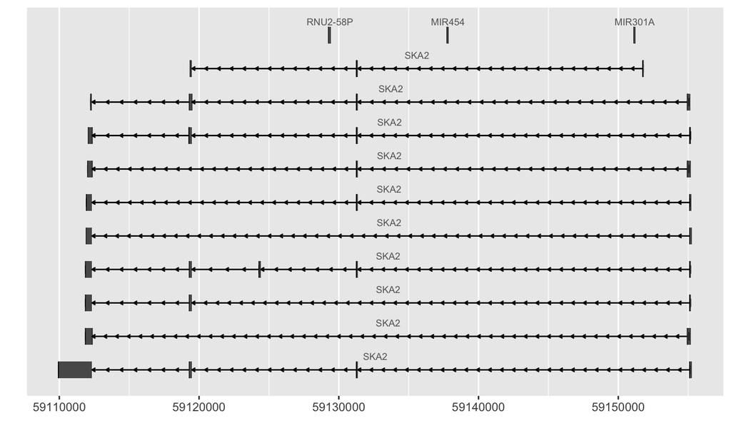

```r
library(ggbio)
## Plot all genes encoded in the same region than SKA2:
ska2 <- genes(edb, filter=GenenameFilter("SKA2"))
## Plot the genomic region; we're using the gene name as labels for the transcripts.
autoplot(edb, GRangesFilter(ska2, condition="overlapping"), names.expr="gene_name")
```

- `Gviz`: `getGeneRegionTrackForGviz` to extract `Gviz`-formatted data.

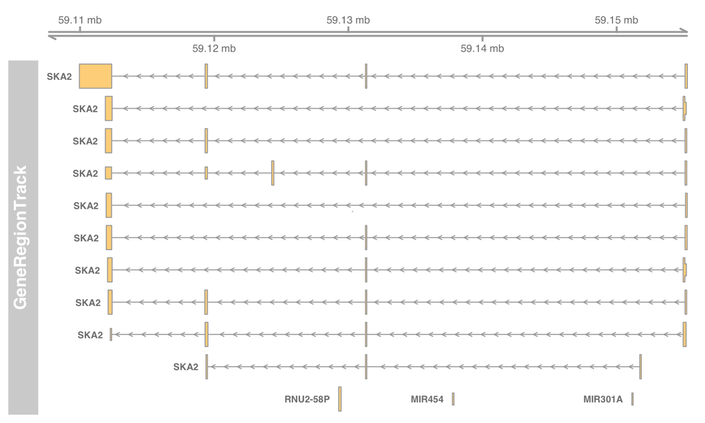

```r
library(Gviz)
## Get a GRanges /formatted/ for Gviz.
grt <- getGeneRegionTrackForGviz(edb, filter=GRangesFilter(ska2, condition="overlapping"))
## Plot the chromosomal region.
plotTracks(list(GenomeAxisTrack(), GeneRegionTrack(grt)), transcriptAnnotation="symbol",
           chromosome=seqlevels(ska2))
```

## The `ensembldb` shiny app

- The `ensembldb` shiny app allows interactive annotation look-up.
- **Example**: search for a gene using the shiny app and return the result to R.

```r
## Run the shiny app:
Result <- runEnsDbApp()

## Inspect the result:
Result
```